# lab_06

Get data

```r
staff <- read_csv("data/instructional-staff.csv")
```

wide to long

```r
staff_long <- staff %>%
  pivot_longer(cols = -faculty_type, names_to = "year") %>%
  mutate(value = as.numeric(value))
```

plot as a line graph incorrect line graph

```
## `geom_line()`: Each group consists of only one observation.
## ℹ Do you need to adjust the group aesthetic?
```

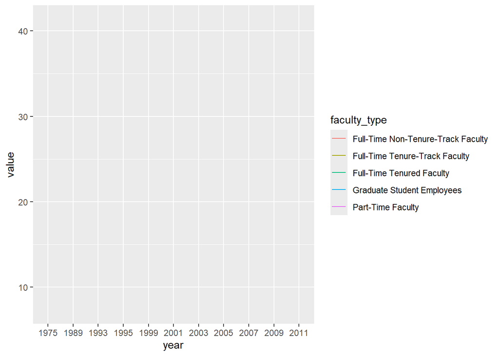

```r
staff_long %>%
  ggplot(aes(x = year, y = value, color = faculty_type)) +
  geom_line()
```

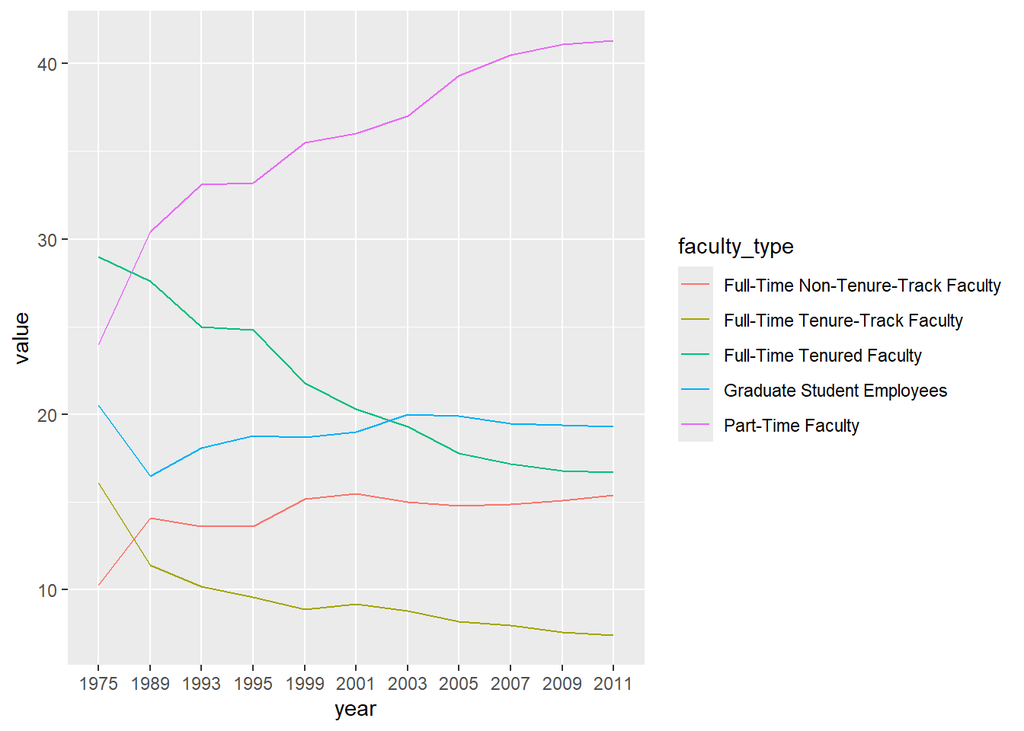

```r
staff_long %>%
  ggplot(aes(
    x = year,
    y = value,
    group = faculty_type,
    color = faculty_type
  )) +
  geom_line()
```

“Suppose the objective of this plot was to show that the proportion of part-time faculty have gone up over time compared to other instructional staff types.”

The proportion for each faculty type is value divided by the sum of all values for that year.

```r
staff_long_propor <- staff_long %>%
  group_by(year) %>%
  mutate(
    proportion = value / sum(value)) %>%
  ungroup()
```

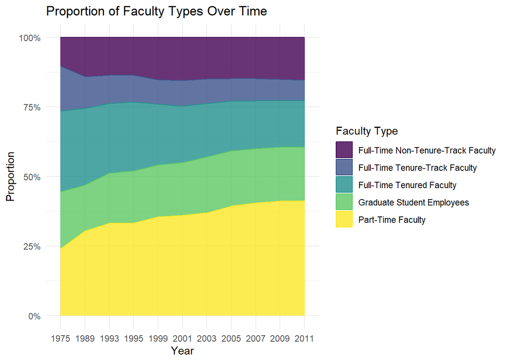

```r
library(viridis)

staff_long_propor %>%
  ggplot(aes(
    x = year,
    y = proportion,
    group = faculty_type,
    color = faculty_type,
    fill = faculty_type
  )) +
  geom_area(alpha = 0.8) +
  scale_fill_viridis_d(option = "viridis") +
  scale_color_viridis_d(option = "viridis") +
  scale_y_continuous(labels = scales::percent_format()) +
  labs(
    title = "Proportion of Faculty Types Over Time",
    x = "Year",
    y = "Proportion",
    fill = "Faculty Type",
    color = "Faculty Type"
  ) +
  theme_minimal()
```

##Fisheries “The Fisheries and Aquaculture Department of the Food and Agriculture Organization of the United Nations (FAO) collects data on the fisheries production of different countries. You can find a list of fishery production for various countries in 2016 on this Wikipedia page. The data includes the tonnage of fish captured and farmed for each country. Note that countries whose total harvest was less than 100,000 tons are excluded from the visualization.”

“Can you help them improve it? First, brainstorm how you would improve it. Then create the improved visualization and document your changes/decisions with bullet points. It’s ok if some of your improvements are aspirational, i.e. you don’t know how to implement it, but you think it’s a good idea. Implement what you can and leave notes identifying the aspirational improvements that could not be made. (You don’t need to recreate their plots in order to improve them)”

in the plot below i - used a stacked bar plot rather than a line plot to make it easier to compare the production of each country - used a viridis color palette to make the graph more visually accessible - Instead of showing the total production–like they did in the initial graph–i focused on the proportion of each type of fishery production for each country. This makes it easier to compare the proportion of each type of fishery production for each country. My graph loses some of the information displayed in the original graph but because china was so much greater than any other country it was hard to compare the other countries meaningfully.

```r
fish <- read_csv("data/fisheries.csv")
fish_longer <- fish %>%
  pivot_longer(cols = -country, names_to = "type", values_to = "total")

fish_proportion <- fish_longer %>%
  group_by(country) %>%
  mutate(total_country = sum(total[type != "total"])) %>%
  filter(type != "total") %>%  # Remove 'total' row
  mutate(proportion = total / total_country) %>%
  ungroup()
```

```r
library(scales)
```

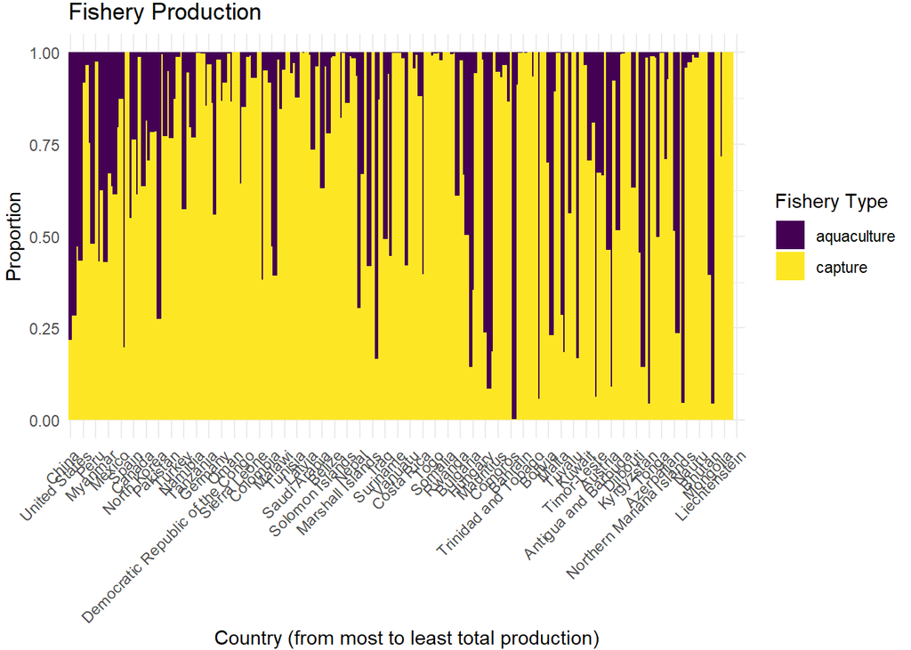

```r
ggplot(fish_proportion, aes(
  x = reorder(country, -total_country),
  y = proportion,
  fill = factor(type)
)) +
  geom_bar(stat = "identity", position = "stack", width = 1.5) +
  scale_fill_viridis_d(option = "viridis") +
  labs(
    title = "Fishery Production",
    x = "Country (from most to least total production)",
    y = "Proportion",
    fill = "Fishery Type"
  ) +
  theme_minimal() +
  theme(
    axis.text.x = element_text(angle = 45, hjust = 1),
    plot.margin = margin(1, 3, 1, 3)
  ) +
  scale_x_discrete(
    breaks = levels(reorder(fish_proportion$country, -fish_proportion$total_country))[
      seq(1, length(unique(fish_proportion$country)), by = 4)
    ]
  )
```

```r
library(tidyverse)
library(mosaicData)
data(Whickham)
```

### Exercise 1

This data seems to be observational beause I doubt that researchers assigned people to smoke or not smoke and then measured if they died or not. This was likely an observational study where they collected data from the population.

### Exercise 2 and 3

There are 1,314 observations in this dataset. Each observation includes an outcome variable (dead or alive) after 20 years, smoker (no or yes), and age at the start of the study. These were all women.

```r
nrow(Whickham)
```

```
## [1] 1314
```

Visualizing outcome variable

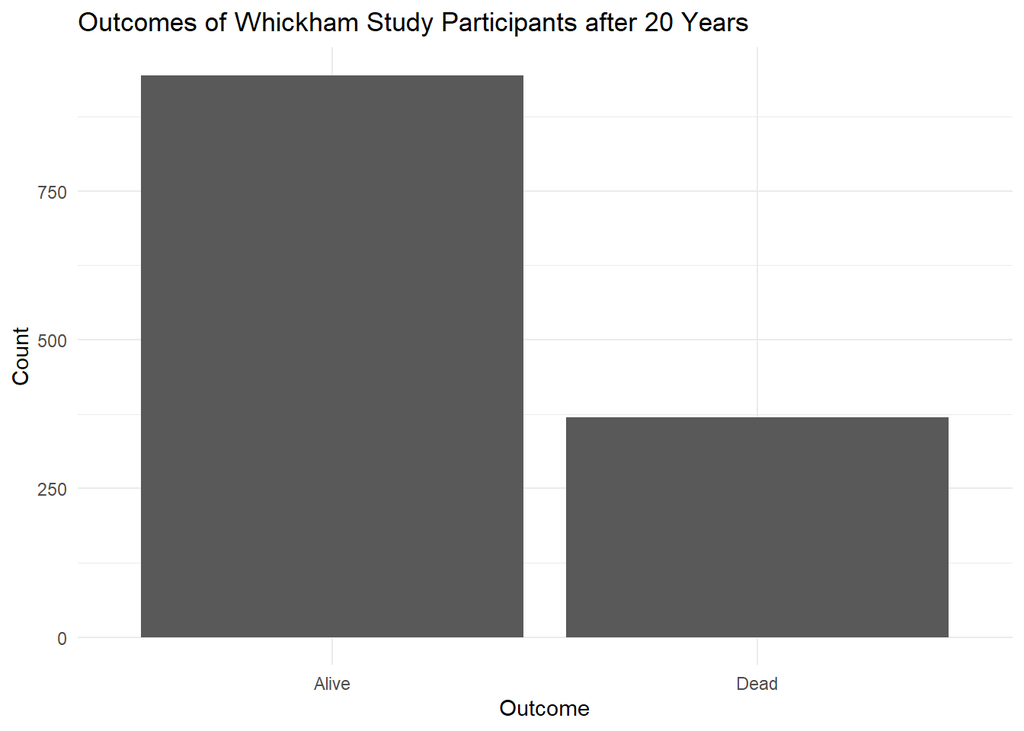

```r
Whickham %>%
  ggplot(aes(x = outcome)) +
  geom_bar()+
  labs(
    title = "Outcomes of Whickham Study Participants after 20 Years",
    x = "Outcome",
    y = "Count"
  ) +
  theme_minimal()
```

Visualizing smoker variable

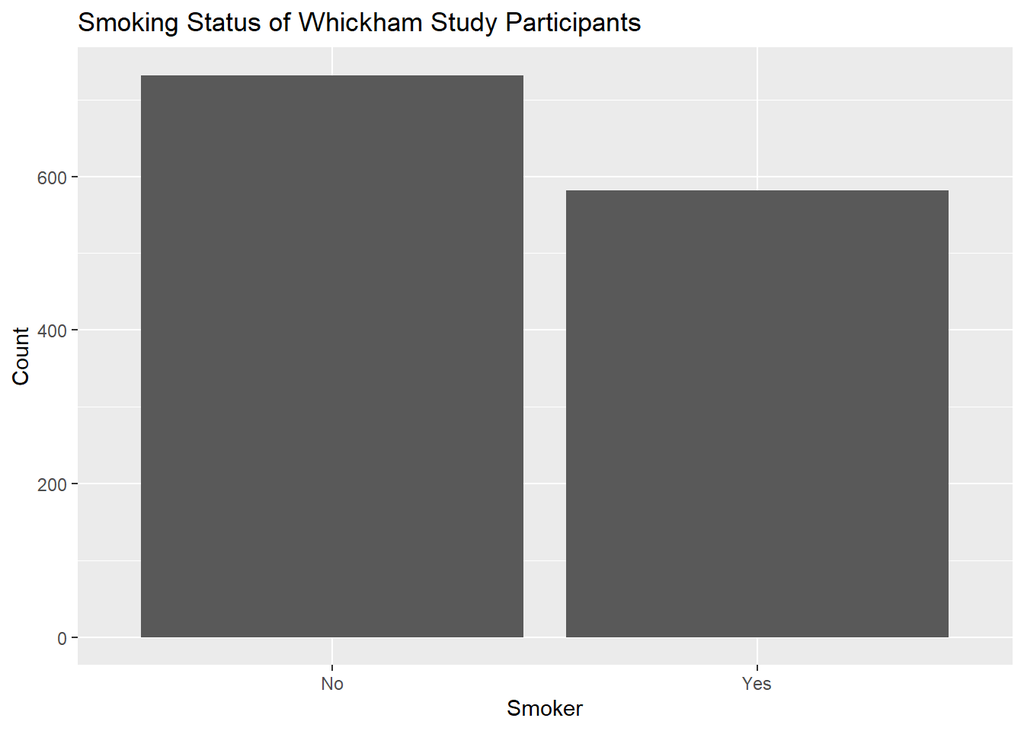

```r
Whickham %>%
  ggplot(aes(x = smoker)) +
  geom_bar()+
  labs(
    title = "Smoking Status of Whickham Study Participants",
    x = "Smoker",
    y = "Count"
  )
```

Visualizing age variable

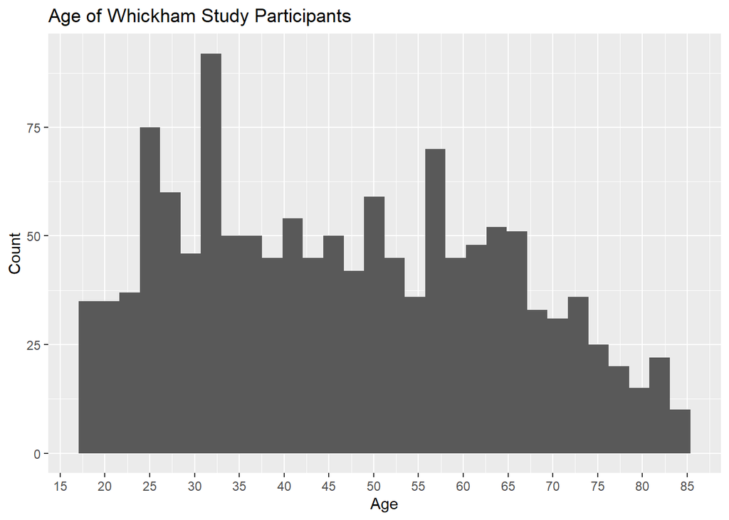

```r
Whickham %>%
  ggplot(aes(x = age)) +
  geom_histogram()+
  scale_x_continuous(breaks = seq(0, 100, by = 5))+
  labs(
    title = "Age of Whickham Study Participants",
    x = "Age",
    y = "Count"
  )
```

### Exercise 4

I would expect that smoking would be associated with a greater likelihood of being dead in 20 years compared to nonsmokers.

### Exercise 5

“Create a visualization depicting the relationship between smoking status and health outcome. Briefly describe the relationship, and evaluate whether this meets your expectations. Additionally, calculate the relevant conditional probabilities to help your narrative.”

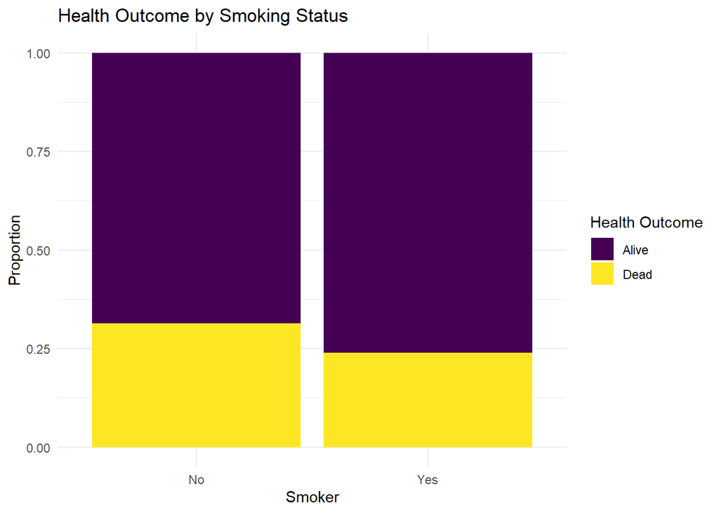

```r
Whickham %>%
  ggplot(aes(x = smoker, fill = outcome)) +
  geom_bar(position = "fill") +
  scale_fill_viridis_d(option = "viridis") +
  labs(
    title = "Health Outcome by Smoking Status",
    x = "Smoker",
    y = "Proportion",
    fill = "Health Outcome"
  ) +
  theme_minimal()
```

It seems that smokers are not more likely to be dead in twenty years compared to nonsmokers which is surprising.

### Exercise 6

“Create a new variable called age_cat”

```r
Whickham <- Whickham %>%
  mutate(age_cat
         = case_when
         (age <= 44 ~ "18-44",
           age > 44 & age <= 64 ~ "45-64",
           age > 64 ~ "65+"))
```

facet wrap

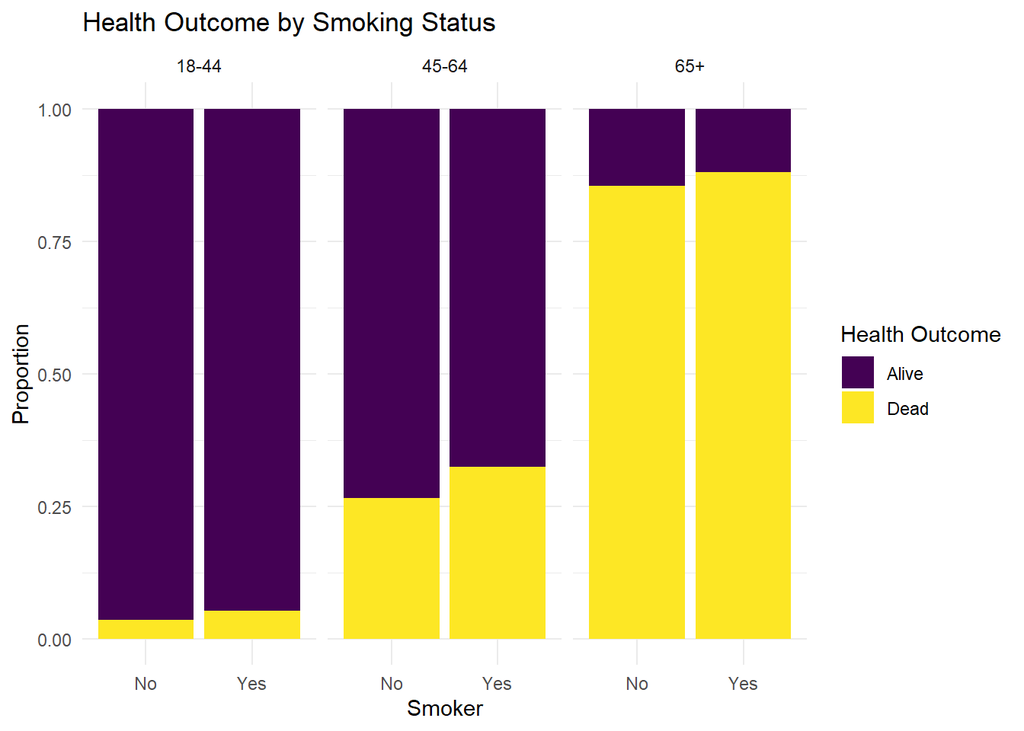

```r
Whickham %>%
  ggplot(aes(x = smoker, fill = outcome)) +
  geom_bar(position = "fill") +
  scale_fill_viridis_d(option = "viridis") +
  labs(
    title = "Health Outcome by Smoking Status",
    x = "Smoker",
    y = "Proportion",
    fill = "Health Outcome"
  ) +
  facet_wrap(~age_cat) +
  theme_minimal()
```

This plot shows that when grouping by these age categories, the relationship between smoking and health outcome is different. For all age groups smoking increases the change of dying 20 years later.

I think this may be caused because the vast majority of the participants were alive rather than dead. This might affect the proportion especially because there are different rates of dying in each age group (older adults are more likely to die regardless of whether they smoked or not).